# CHAPTER A 15

# 閉じた薄肉断面におけるせん断流

## A15.1 はじめに

現代の航空機の翼、胴体、および尾翼構造は、本質的に薄いウェブと壁を持つ単一または複数のセル状の梁である。このような構造の設計には、内部の抵抗せん断応力の分布を考慮することが含まれる。本章では、せん断流分布の一般的な問題について学生に紹介する。本章を学習する前に、第 A14 章を履修しておく必要がある。

## A15.2 単一セル梁。1軸対称。すべての材料が曲げ応力への抵抗に有効であるとする。

図 A15.1 は、図に示すように 100 lb. の荷重を支持する単一セルの矩形梁を示している。問題は、断面 abcd における内部の抵抗せん断流パターンを見つけることである。

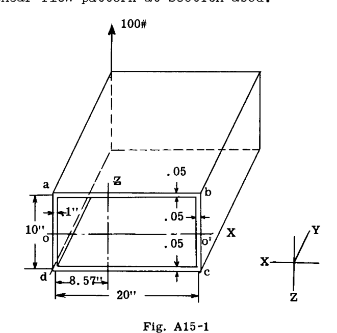

図 A15-1

### 解法 1

材料の対称性により、X 図心軸は梁の高さの中央に位置する。せん断流の式には、X 軸に関する断面の慣性モーメント $I_x$ の値が必要である。

$$I_x = \frac{1}{12} \times .15 \times 10^3 + 2 \left[ 20 \times .05 \times 5^2 \right] = 62.5 \text{ in.}^4$$

第 A14 章より、せん断流の式は、

$$q_y = -\frac{V_z}{I_x} \Sigma z A \quad \text{--- (1)}$$

この式は、累積の限界間におけるせん断流の変化を与える。開断面では、せん断流 $q$ がゼロとなる自由表面から累積を開始することができ、したがって他の任意の点への累積によって真のせん断流 $q_y$ が得られる。閉じたセルでは自由端が存在しないため、任意の点における $q_y$ の値は未知である。

式 (1) は、ねじれを伴わない X 軸まわりの曲げに対するせん断分布を与える。一般的な手順は、ある点におけるせん断流 $q_y$ の値を仮定し、与えられた外荷重の下でねじれを伴わない曲げに対するせん断流パターンを見つけることである。この内部せん断流系の図心は、ねじれを伴わない曲げのために外せん断荷重が作用すべき位置となる。与えられた外せん断力はこの図心まわりにモーメントを持つため、この不釣り合いモーメントは、セルに一定のせん断流系を加えることによってゼロにされなければならない。

説明のために、ウェブ ad 上の点 O において $q_y$ がゼロであると仮定する。

$$q_O = 0$$

項 $\frac{V_z}{I_x} = 100 / 62.5 = 1.6$

$$q_{ao} = -1.6 \sum_O^a z A = -1.6 \times 2.5 \times 5 \times 0.1 = -2 \text{ lb/in.}$$

$$q_{ba} = -2 - 1.6 \sum_a^b z A = -2 - 1.6 \times 5 \times 20 \times .05 = -10$$

$$q_{O'b} = -10 - 1.6 \sum_b^{O'} z A = -10 - 1.6 \times 2.5 \times 5 \times .05 = -11$$

$$q_{co'} = -11 - 1.6 \sum_{O'}^c z A = -11 - 1.6 \times (-2.5) \times 5 \times .05 = -10$$

$$q_{cd} = -10 - 1.6 \sum_c^d z A = -10 - 1.6(-5) \times 20 \times .05 = -2$$

$$q_{od} = -2 - 1.6 \sum_d^O z A = -2 - 1.6(-2.5) \times 5 \times 0.1 = 0$$

図 A15.2 は、せん断流の結果のプロットを示している。垂直ウェブ上では、面積が距離 $z$ に直接比例して変化するため、せん断力の増加は放物線状になる。

断面の平面における $q_x$ および $q_z$ の強さは、上述の $y$ 方向に見出された $q$ の値に等しい。 $q_x$ および $q_z$ の向きは、第 A14 章の A14.6 節で詳細に説明されているように決定される。

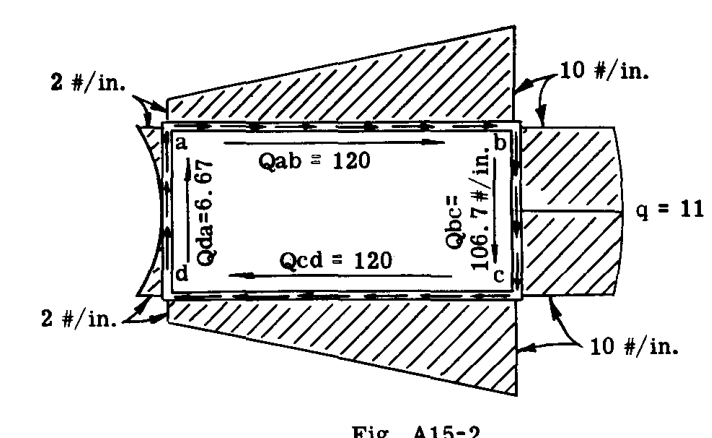

図 A15-2

図 A15.2 はまた、セルの4つの壁のそれぞれにおける合力せん断流力を示している。各位置における合力せん断力は、各位置のせん断流図の面積に等しい。

例えば、

$$Q_{ab} = (\frac{2 + 10}{2}) 20 = 120 \text{ lb.}$$

$$Q_{da} = \frac{1}{3} \times 2 \times 10 = 6.67 \text{ lb.}$$

$$Q_{bc} = 10 \times 10 + 0.667 \times 1 \times 10 = 106.7$$

図 A15.2 に示す内部せん断流力系は、図 A15.1 に示す 100 lb. の与えられた外せん断荷重との平衡状態がチェックされる。

$$\Sigma F_z = 100 \text{ (external)} + 6.67 - 106.67 = 0 \text{ (check)}$$

$$\Sigma F_x = 120 - 120 = 0 \text{ (check)}$$

モーメントの平衡も満たされなければならない。点 d のまわりのすべての力のモーメントをとる。外荷重は d まわりにモーメントを持たない。

3334 in. lb. の不釣り合いモーメントは、セルのまわりに反時計回りの方向に一定のせん断流を加えることによって釣り合わせることができる。この釣り合いせん断流の値は、次のように等しくなる。

$$q = -\frac{M}{2A} = -\frac{3334}{2 \times 200} = -8.34 \text{ lb/in.}$$

( $A$ はセルの面積 = $10 \times 20$ )

この一定のせん断流を図 A15.2 のせん断流に加えることにより、図 A15.3 の最終的なせん断流パターンが得られる。

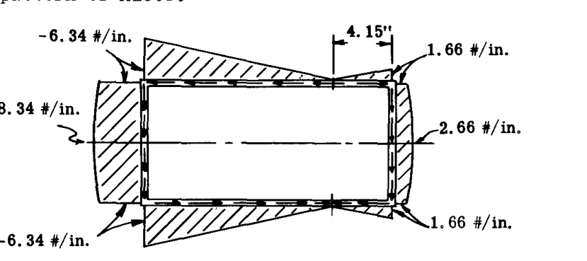

図 A15-3

もしこの $-8.34$ の一定のせん断流が加えられなかった場合、100 lb. の外荷重は、図 A15.2 のせん断流パターンの図心を通るように再配置されなければならない。この図心位置を見つけるために、ある点まわりの内部せん断流パターンのモーメントを、同じ点まわりの系の合力のモーメントと等しく置くことができる。

$$\text{Resultant } R = \sqrt{\Sigma F_x^2 + \Sigma F_z^2} = \sqrt{100^2 + 0} = 100 \text{ acting down.}$$

点 d まわりのモーメントをとる。合力への距離を $\bar{x}$ とする。

$$R \bar{x} = \Sigma M_d \text{ (internal system)}$$

$$100 \bar{x} = 120 \times 10 + 106.7 \times 20$$

したがって $\bar{x} = 33.33 \text{ in.}$ となる。したがって、図 A15.2 のパターンが平衡を保つためには、外荷重を右に 33.33 インチ移動させる必要がある。点 O において $q = 0$ と仮定しているため、これは、点 O に自由端を持つ開いたセルは、外荷重が距離 $\bar{x}$ だけ移動された場合にねじれを伴わずに曲がることを意味する。

学生は、上記解法で仮定した点 O の代わりに、他の任意の点において $q$ がゼロであると仮定して、この同じ問題を解くべきである。

### 解法 No.2。せん断中心法

この解法では、閉じた断面がねじれを伴わずに X 軸まわりに曲がる場合の内部せん断流系の図心を決定する。この点はせん断中心と呼ばれる。外せん断荷重は、せん断中心に作用するせん断力と、せん断中心まわりのねじりモーメントに分解することができる。

解法 1 と全く同様に、点 O においてせん断流 $q = 0$ と仮定して解法を開始する。ある意味では、セルを O で切断して開断面にしている。得られるせん断流は 図 A15.2 に示す通りである。この開断面は、外せん断荷重が開断面のせん断中心に作用する場合、ねじれを伴わずに曲がる。

閉じた断面はねじれを伴わずに曲がると仮定し、結果として生じるせん断流パターンが決定される。

梁の単位長さあたりの角ねじれ $\theta$ の式（第 A6 章を参照）は、

$$\theta = \frac{1}{2AG} \sum \frac{qL}{t} \quad \text{, ここで L はウェブまたは壁の長さを表す。}$$

または

$$2A\theta = \frac{1}{G} \sum \frac{qL}{t}$$

この式の右辺は、セルの周囲の全せん断ひずみを表しており、セルのねじれがないためにはゼロでなければならない。 $G$ は一定であるため、解法にはひずみの相対値のみが必要であるから、これを 1 と仮定することができる。したがって、セルの周囲の全せん断ひずみ $\delta$ は、以下に比例する。

$$\delta = \sum \frac{qL}{t} \quad \text{--- (2)}$$

図 A15.2 からの $q$ の値を使用し、式 (2) に代入すると、

$$\delta = \sum \frac{qL}{t} = \left[ \frac{2 \times 5}{3 \times .1} + \frac{(10 + 2) 20}{2 \times .05} + \frac{10 \times 5}{.05} + \frac{(11 - 10)(.667 \times 5)}{.05} \right] 2 = 7000$$

断面とせん断流パターンは X 軸に関して対称であるため、上記の代入はセルの半分に対して書かれ、結果に 2 を乗じている。せん断流 $q$ が一部の区間で変化する場合、上記の代入では平均せん断流が使用される。

セルがねじれないようにするためには、7000 の相対的なねじれを、セルのまわりに一定のせん断流 $q$ を加えて $-7000$ の全せん断ひずみを与えることによって相殺しなければならない。

一定の $q$ に対するせん断ひずみは、次のように等しくなる。

$$\delta = \sum \frac{qL}{t} = q \left[ \frac{5}{0.1} + \frac{20}{.05} + \frac{5}{.05} \right] 2 = -7000$$

図 A15.4 は、 $-6.36$ の一定のせん断流を図 A15.2 のせん断流パターンに加えた場合の、結果として生じるせん断流パターンを示している。

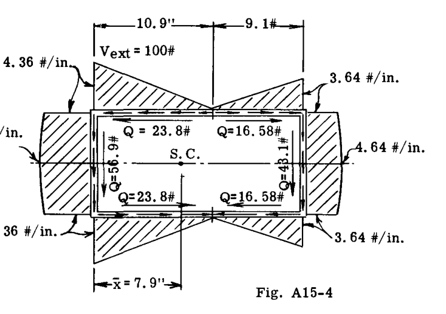

図 A15-4

図 A15.4 のせん断流力系の合力の位置は、せん断中心の水平位置を位置づける。断面が X 軸に関して対称であるため、せん断中心の垂直位置は X 軸上にある。なぜなら、Z 軸まわりの曲げに対して、せん断流は対称となり、したがって合力は X 軸と一致するからである。

図 A15.4 はまた、図のように様々な部分のせん断流図の面積に等しい、セル壁の各部分における合力荷重 $Q$ を示している。

$$\Sigma F_z = -56.9 - 43.1 = -100 \text{, これは 100 lb. の外荷重と釣り合う。}$$

$$\Sigma F_x = 0 \text{ (観測による)}$$

X 軸と側壁 ad の交点である点 O まわりのモーメントをとる。

$$\bar{x} = \frac{\Sigma M_O}{\Sigma F_z} = \frac{43.1 \times 20 + (-23.8 + 16.58)10}{100} = 7.90 \text{ in.}$$

したがって、せん断中心は X 軸上、側壁 ad から 7.9 インチの位置にある。

せん断中心まわりの 100 lb. の外荷重のモーメントは、

$$100 \times 7.9 = 790 \text{ in. lb. clockwise}$$

に等しい。図 A15.4 の内部せん断流のモーメントはゼロであるため、不釣り合いなモーメントが 790 生じる。したがって、モーメントの平衡のために、セルのまわりに $-790$ in. lb. のモーメントを発生させるために一定のせん断流 $q$ を加えなければならない。すなわち、

$$q = -\frac{M}{2A} = -\frac{790}{2 \times 200} = -1.98 \text{ lb/in.}$$

この一定のせん断流を図 A15.4 のせん断流に加えることにより、図 A15.3 に示すもの、または解法 1 の結果と同一になる最終的なせん断流パターンが得られる。

## A15.3 単一セル - 2フランジ梁。一定せん断流ウェブ。

A14.9 節で議論したように、一般的な航空機のセル状梁は、通常フランジ部材と呼ばれる部材によって補強された薄いシート壁とウェブで構成されている。一般的な簡略化の仮定は、フランジ部材のみが曲げモーメントに対する抵抗を発生させると仮定することである。したがって、この仮定は、フランジ部材間のせん断流が一定であることを意味する。

図 A15.5 は、A と B に2つのフランジを持つ単一セル梁を示している。梁が示すように 100 lb. の外荷重を支持しているときの内部せん断流力系を見つけよ。

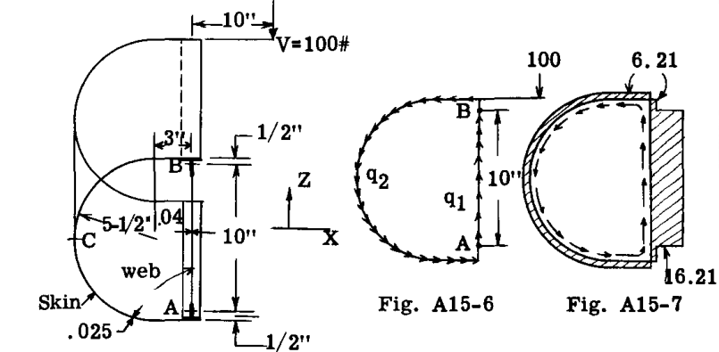

図 A15-5, 図 A15-6, 図 A15-7

2つのフランジが曲げ応力抵抗のすべてを発生させると仮定されている。これは、各ウェブ上でせん断流が一定であることを意味する。図 A15.6 に示すように、一定のせん断流を $q_1$ および $q_s$ とする。これらのせん断流の向きまたは方向は、図の矢印で示されるように仮定される。

断面の平面における力系には2つの未知数、すなわち $q_1$ と $q_s$ があり、したがって単純な静力学によって $q_1$ と $q_s$ を解くことができる。

$q_s$ を見つけるために、点 A まわりのモーメントをとる。

$$\Sigma M_A = 100 \times 10 - q_s(2 \times 80.52) = 0$$

したがって、

$$q_s = 1000 / 161.04 = 6.21 \text{ lb/in.}$$

$q_s$ の符号はプラスとして出てくるため、図 A15.6 に示す $q_s$ の仮定された向きは正しい。

点 A まわりの上記のモーメントの式において、A まわりの一定流系 $q_s$ のモーメントは、 $q_s$ に、A からせん断流 $q_s$ を運ぶウェブの端部まで走る線によって形成される囲まれた面積の2倍を掛けたものに等しい。この場合、面積はセルの面積、すなわち 80.52 sq. in. である。

残りの未知数 $q_1$ を見つけるために、平衡方程式を使用する。

$$\Sigma F_z = 0 = -100 - 10 \times 6.21 + 10 q_1 = 0$$

したがって、

$$q_1 = 16.21 \text{ lb/in. (符号は正として出てくるため、仮定した q_1 の向きは正しい)}$$

図 A15.7 は、内部せん断流抵抗系のプロットを示している。

2つのフランジのみを持つ単一セル梁は、線 AB に平行な外荷重にのみ抵抗することができ、したがって2フランジボックス梁は航空機構造ではあまり頻繁に使用されない。線 AB に直交する平面における曲げモーメントが小さい場合、圧縮曲げ応力に対する湾曲パネルの抵抗が、このような外側の曲げモーメントに抵抗するのに十分であり、したがって満足のいくものである可能性がある。

## A15.4 単一セル - 2フランジ梁のせん断中心。

図 A15.5 に示す梁のせん断中心を見つけることが求められているとする。言い換えれば、梁がねじれを伴わずに曲がるためには、外荷重をどこに配置しなければならないか。

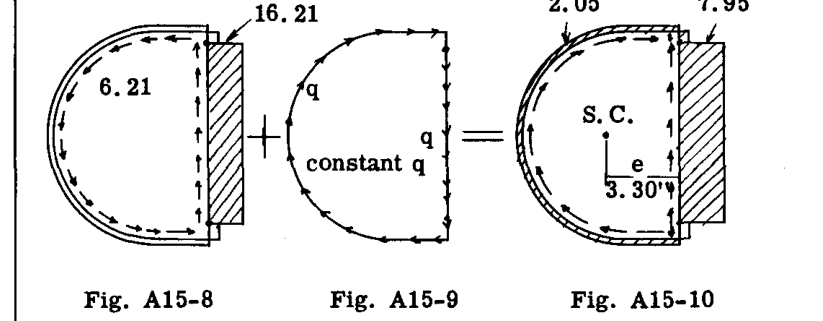

図 A15-8, 図 A15-9, 図 A15-10

図 A15.8 は、図 A15.5 に示すように作用する 100 lb. の外荷重に抵抗する際の結果として生じるせん断流系を示している。このせん断流系はセルをねじれさせる。したがって、ねじれをゼロにするために、セルに一定のせん断流 $q$ を加える（図 A15.9）。組み合わされたせん断流系の図心は、その後、せん断中心の横方向の位置を位置づける。

$q$ を見つけるために、図 A15.8 および 9 のせん断流を受けたときのねじれを測定する式を書き、その結果をゼロと等しく置き、次いで1つの未知数 $q$ について解かなければならない。

$$\delta = \sum \frac{qL}{t} = 0 \quad \text{(時計回りの q は正とする)}$$

図 A15.8 および A15.9 のせん断流を使用して代入すると、

$$\delta = -\frac{16.21 \times 10}{.04} - \frac{6.21 \times 24.28}{.025} + \frac{10q}{.04} + \frac{24.28q}{.025} = 0$$

したがって、

$$q = 8.26 \text{ lb/in.}$$

この一定のせん断流を図 A15.8 のせん断流に加えることにより、図 A15.10 のせん断流が得られる。

せん断中心の横方向の位置は、図 A15.10 のせん断流系の合力の位置によって与えられる。

合力 $R = \sqrt{\Sigma F_x^2 + \Sigma F_z^2}$

$$\Sigma F_x = 0$$

$$\Sigma F_z = 10
\times 7.95 + 2.05 \times 10 = 100 \text{ lb.}$$

したがって、

$$R = 100 \text{ lb.}$$

点 A まわりの R のモーメントを、A まわりのせん断流系のモーメントと等しく置く。

$$R e = \Sigma M_A$$

$$100 e = 2.05 (2 \times 80.52)$$

したがって、せん断中心は線 AB の左側 3.30 インチの位置にある。（図 A15.10 を参照）。

したがって、100 lb. の与えられた外荷重がせん断中心を通って作用する場合、図 A15.10 のせん断流系が発生する。しかし、それはせん断中心の右側 13.3 に作用するため、セル上に $100 \times 13.3 = 1330$ in. lb. の時計回りのモーメントを発生させる。平衡のために、このモーメントは、 $-1330$ のモーメントを発生させるセルのまわりの一定の抵抗せん断流によって釣り合わされなければならない。

必要な $q = \frac{-1330}{2 \times 80.52} = -8.26 \text{ lb. in.}$

これを図 A15.10 のせん断流系に加えると、図 A15.8 の真のせん断流系が得られる。

このようにせん断中心位置を持つことにより、外荷重系は、せん断中心を通る荷重に分解され、さらにせん断中心まわりのモーメントに分解される。それぞれによるせん断流を加えて、真の抵抗せん断流を与える。

ウェブまたは皮皮の厚さは、単一セル梁におけるせん断流系の大きさには影響しないことに注意すべきである。しかし、厚さの変化は単位せん断応力、したがってせん断ひずみに影響を与え、したがってセルの角ねじれを計算する際、ウェブと壁の厚さは、与えられたねじり荷重に対するねじれの量に影響を及ぼす。せん断中心の解法では、せん断流のどの部分がトルクまたは純粋なねじれによるものであり、またどの部分がねじれを伴わない曲げによるものであるかが分かっており、この事実は時に重要である。

### セルのねじりたわみ

図 A15.8 の最終的なせん断流パターンによって与えられる角ねじれは、 $2A\theta G = \Sigma q L / t$ に等しく、ここから、

$$2A\theta G = -\frac{6.21 \times 24.28}{.025} - \frac{16.21 \times 10}{.04} = -10082 \quad \text{--- (3)}$$

せん断中心位置を見つけた後、外荷重がせん断中心まわりに 1330 in. lb. のモーメントを持っていることを見出し、これは $-8.26$ lb/in. の一定のせん断流によって抵抗された。したがって、この純粋なトルクせん断流の下での角ねじれは、上記の式 (3) と同じ結果を与えるはずである。

$$2A\theta G = -\frac{8.26 \times 24.28}{.025} - \frac{8.26 \times 10}{.04} = -10082$$

これは式 (3) の結果と一致する。

## A15.5 単一セル - 3フランジ梁。一定せん断流ウェブ。

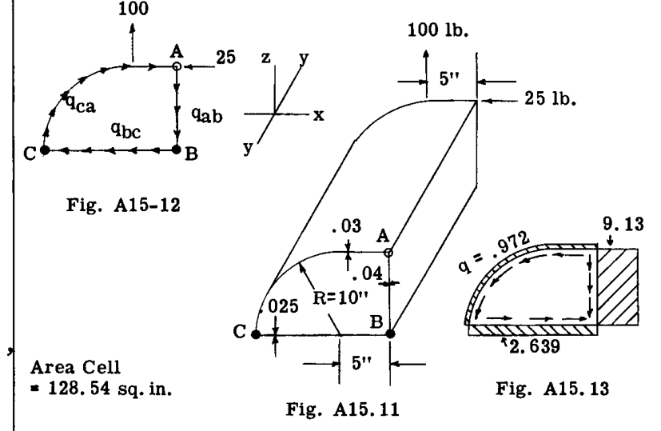

図 A15-11, 図 A15-12, 図 A15-13

図 A15.11 は、示すように外荷重を支持する、3つのフランジ部材 A、B、および C を持つ単一セル梁を示している。フランジが直線上に配置されていない場合、3フランジボックスは任意の方向の曲げを受けることができるため、その単純さから設計においてよく使用される。

このような構造については、6つの未知数、すなわち各ストリンガーにおける軸方向荷重と、セルを構成する3つのシートパネルのそれぞれにおけるせん断流 $q$ がある。空間構造については、6つの静的平衡方程式があり、したがって3フランジ単一セル梁は、3つのフランジ部材がすべての曲げ応力抵抗を発生させ、それによって一定のせん断流ウェブを生成すると仮定すれば、静力学によって解くことができる。

図 A15.12 は、断面 ABC を示している。3つの未知の抵抗せん断流は正の符号で仮定されている。（時計回りの流れを正のせん断流とする）。これらの3つの未知のせん断流は、静力学によって決定することができる。

$q_{ca}$ を見つけるために、点 B まわりのモーメントをとり、ゼロと等しく置く。

$$\Sigma M_B = 100 \times 5 - 25 \times 10 + q_{ca}(128.54 \times 2) = 0$$

したがって、

$$q_{ca} = -\frac{250}{257.08} = -0.972 \text{ lb/in.}$$

$q_{ab}$ を見つけるために、 $\Sigma F_z = 0$ とする。

$$\Sigma F_z = 100 - 10 \times 0.972 - 10 q_{ab} = 0$$

$$q_{ab} = 9.13 \text{ lb/in.}$$

$q_{bc}$ を見つけるために、 $\Sigma F_x = 0$ とする。

$$\Sigma F_x = -15 \times 0.972 - 25 - 15 q_{bc} = 0$$

したがって、

$$q_{bc} = -2.639 \text{ lb/in.}$$

$q_{ca}$ および $q_{bc}$ の符号が負として出てきたため、これらのセル壁部分におけるせん断流の向きは、図 A15.12 で仮定されたものとは逆である。結果として得られるせん断流パターンは、図 A15.13 にプロットされている。

学生は、3つのフランジが曲げモーメントに対する全体の抵抗を発生させると仮定した場合、壁要素の厚さはせん断流分布に影響を与えないことを認識すべきである。

## A15.6 単一セル - 3フランジ梁のせん断中心。一定せん断流ウェブ。

図 A15.11 に示す梁のせん断中心位置を決定することが求められているとする。せん断中心は、セルがねじれを伴わずに曲がるために、合力の外せん断力が作用しなければならない梁断面上の点である。

せん断中心位置は2つのステップで決定され、最初にその水平位置、次にその垂直位置が決定される。

### 水平位置の計算:-

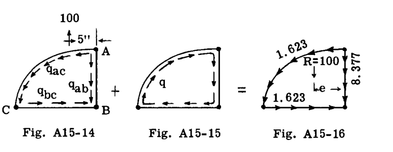

図 A15-14, 図 A15-15, 図 A15-16

3つの未知の抵抗せん断流は、矢印の頭で示される向きを持つと仮定される。

$q_{ac}$ を見つけるために、B まわりのモーメントをとる。

$$\Sigma M_B = 100 \times 5 - q_{ac}(128.54 \times 2) = 0$$

$$q_{ac} = 1.945 \text{ lb/in.}$$

$$\Sigma F_x = -15 \times 1.945 + 15 q_{bc} = 0$$

$$q_{bc} = 1.945$$

$$\Sigma F_z = 100 - 10 \times 1.945 - 10 q_{ab} = 0$$

$$q_{ab} = 8.055 \text{ lb/in.}$$

未知の $q$ 値の代数符号はすべて正として出てくるため、図 A15.14 におけるせん断流の仮定された方向は正しい。

セルのねじれをゼロにするために、セルに一定のせん断流 $q$ を加えなければならない（図 A15.15 を参照）。図 14 と 15 のせん断流の下での相対的なねじれをゼロと等しく置く。

$$\sum \frac{qL}{t} = -\frac{1.945 \times 20.71}{.03} - \frac{1.945 \times 15}{.025} + \frac{8.055 \times 10}{.04} + \frac{20.71q}{.03} + \frac{10q}{.04} + \frac{15q}{.025} = 0$$

これより、図 A15.15 で仮定された向きで $q = 0.322$ lb/in. となる。この一定のせん断流を図 A15.14 のせん断流に加えることにより、図 A15.16 のせん断流系が得られる。外荷重が 100 lb. であったため、このせん断流系の合力 R は明らかに 100 lb. である。したがって、この合力 R の位置が、せん断中心の水平位置を位置づける。合力 R の点 B まわりのモーメントを、B まわりのせん断流系のモーメントと等しく置き、これより、

$$100 e = 1.623 (128.54 \times 2)$$

または $e = 417 / 100 = 4.17$ in. 線 AB から（図 A15.16）。

### せん断中心の垂直位置の計算

都合の良い水平せん断荷重がセルに作用すると仮定される。

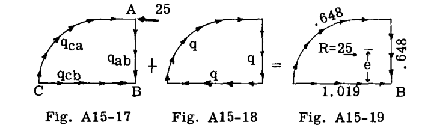

図 A15-17, 図 A15-18, 図 A15-19

A15.5 節の例題で 25 lb. の荷重を使用したため、この解法でも同じ荷重を想定する。図 A15.17 は、荷重と 3つの未知のせん断流の仮定された方向を示している。

図 A15.17 における 3つの未知のせん断流について解く。

$$\Sigma M_B = -25 \times 10 + q_{ca}(128.54 \times 2) = 0$$

$$q_{ca} = 0.972 \text{ lb/in.}$$

$$\Sigma F_x = -25 + .972 \times 15 + 15 q_{cb} = 0$$

$$q_{cb} = 0.695$$

$$\Sigma F_z = 10 \times 0.972 - 10 q_{ab} = 0$$

$$q_{ab} = 0.972$$

ねじれをゼロにするために、セルに一定のせん断流 $q$ が加えられる（図 A15.18）。

両方の荷重に対して $\Sigma q L / t$ を書き、ゼロと等しく置く:-

$$\sum qL/t = \frac{0.972 \times 20.71}{.03} - \frac{0.695 \times 15}{.025} + \frac{0.972 \times 10}{.04} + \frac{20.71q}{.03} + \frac{10q}{.04} + \frac{15q}{.025} = 0$$

これより、

$$q = -0.324 \text{ lb/in.}$$

この一定のせん断流を図 A15.17 のせん断流に加えることにより、図 A15.19 に示す値が得られる。

$$R \text{ (the resultant)} = 25 \text{ lb.}$$

合力の B まわりのモーメントを、B まわりのせん断流系のモーメントと等しく置く。

$$R e = \Sigma M_B$$

$$25 e = 0.648 (128.54 \times 2)$$

したがって、

$$e = 6.65 \text{ inches.}$$

したがって、せん断中心は B の上方に 6.65 インチ、および以前に見出されたように B の左方に 4.17 インチの位置にある。

## A15.7 単一セル - 複数フランジ - 1軸対称。

図 A15.20 は、100 lb. のせん断荷重を支持する、8つのフランジ部材を持つ単一セル梁を示している。抵抗せん断流系が計算される。

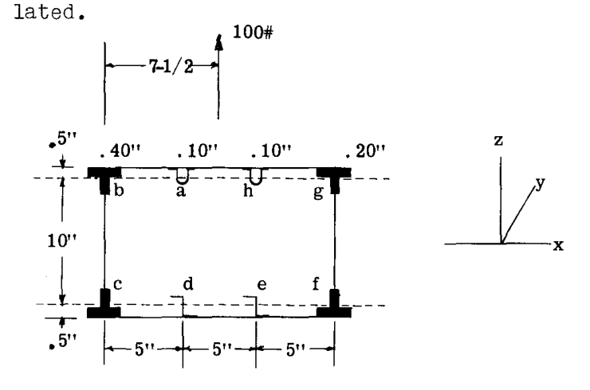

図 A15-20

X 軸に関して対称な梁断面は、A14.10 節の例題 1 で使用されたフランジ材料に関する梁断面と同一である。

### 解法:-

8つのフランジがすべての曲げ応力抵抗を発生させると仮定すると、せん断流はフランジ間で一定となる。梁断面は閉じたものであるため、任意の点におけるせん断流 $q$ の値は未知である。したがって、フランジ部材 a と h の間で上部カバーが切断されていると想像し、それによって切断部における自由端のために、このパネルにおいて $q$ がゼロになるとする。ここで、外せん断荷重 $V_z = 100$ lb. の下での、x-x 軸に関するこの開断面の曲げに対する内部抵抗せん断流系を見つける。

計算は A14.10 節の例題 1 のものと全く同様であるため、ここでは繰り返さない。図 A15.21 は、図 A14.32 から再コピーされたプロットされた結果を示している。

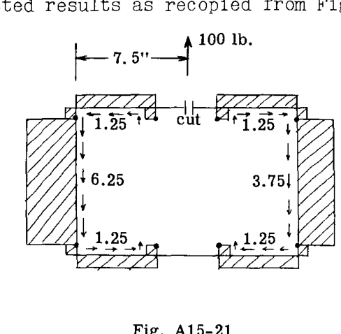

図 A15-21

外荷重と内荷重の平衡について $\Sigma F_x$ および $\Sigma F_z$ が考慮される場合、それらはゼロに等しいことがわかる。

$\Sigma M_y = 0$ をチェックするために、C などのある点まわりのモーメントをとる。

$$\Sigma M_C = -100 \times 7.5 + 10 \times 3.75 \times 15 - 1.25 \times 5 - 1.25 \times 10 + 1.25 \times 15 = -187.5 \text{ in. lb.}$$

したがって、 $\Sigma M_C = 0$ にするために、

$$q = M / 2A = (187.5 / 2 \times 11 \times 15) = 0.57 \text{ lb./in.}$$

に等しい一定のせん断流が必要である。この一定のせん断流を図 A15.21 のせん断流に加えることにより、図 A15.22 の最終的なせん断流パターンが得られる。この最終的なパターンは図 A15.21 のものと大きく異ならない。その理由は、 $q$ をゼロにするための仮想の切断の位置が、このパネルにおける最終的な $q$ がわずか 0.57 であったため、真の事実から遠くなかったからである。もしウェブ bc が切断されている、あるいは $q_{bc} = 0$ と仮定して解法を開始していた場合、 $\Sigma M_y = 0$ を満たすために必要となる補正の一定流は $q = -5.88$ となったはずである。これはウェブ bc における最終的な $q$ であるからである。セル壁上の荷重であるせん断流は、必要とされるシートの必要厚さに影響を与えるため、ルーチン設計における皮皮厚さに関する予備的な見積もりが、最終的な値に近いせん断流の値に基づき得るように、せん断力がゼロに近い点に仮想の切断を配置するように試みることが良いプラクティスである。

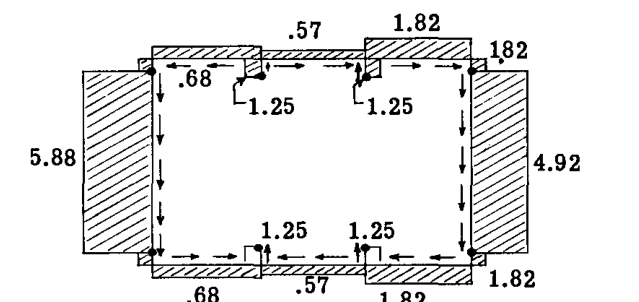

図 A15-22

## A15.8 単一セル - 非対称 - 複数フランジ。

### 例題 1

図 A15.23 は、示すように2つの外荷重を支持する、4フランジの非対称単一セル梁を示している。この梁は、曲げ応力を扱った A13.8 節の例題 1 で使用されたものと同一である。

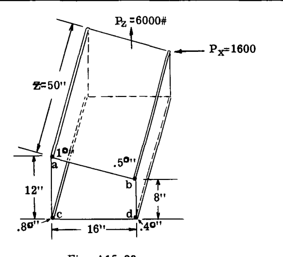

図 A15-23

#### 解法 1. 図心軸を基準とした断面特性と外せん断の使用（K 法）

A13.8 節において、この梁断面の計算により、以下が与えられた:-

$$I_x = 81.18 \text{, } I_z = 153.58 \text{, } I_{xz} = -21.33$$

図 A15.23a は、x および z 図心軸の位置を示している。

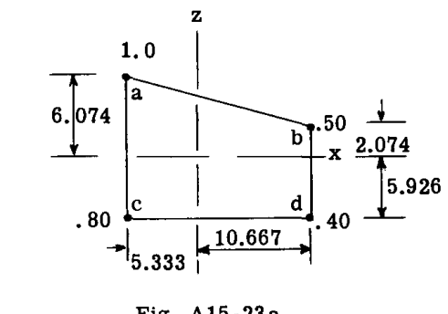

図 A15-23a

第 A14 章の A14.8 節において、解法は K 法と言及された。せん断流の式（A14.8 節の式 14 を参照）は、

$$q_y = -(k_3 V_x - k_1 V_z) \sum x A - (k_2 V_z - k_1 V_x) \sum z A$$

$$k_1 = I_{xz} / (I_x I_z - I_{xz}^2) = \frac{-21.33}{81.18 \times 153.58 - 21.33^2} = \frac{-21.33}{12016} = -.001775$$

$$k_2 = I_z / (I_x I_z - I_{xz}^2) = 153.58 / 12016 = .01279$$

$$k_3 = I_x / (I_x I_z - I_{xz}^2) = 81.18 / 12016 = .00674$$

与えられた梁の荷重に対して、断面 abcd における外せん断荷重は、

$$V_z = 6000 \text{ lb., } V_x = -1600 \text{ lb.}$$

である。上記で与えられた $q_y$ の式に代入すると、

$$q_y = - \left[ .00674(-1600) - (-.00177 \times 6000) \right] \sum x A - \left[ .01279 \times 6000 - (-.00177)(-1600) \right] \sum z A$$

これより、

$$q_y = 0.16 \sum x A - 73.91 \sum z A \quad \text{--- (4)}$$

式 (4) を使用してせん断流パターンを計算する際、上部パネル ab が切断されていると想像し、それによってこのパネルにおけるせん断流 $q_y$ をゼロにする。式 (4) に代入すると、

$$q_{ac} = 0 + .16 \times 1 (-5.333) - 73.91 \times 1 \times 6.074 = -449.78 \text{ lb/in.}$$

$$q_{cd} = -449.78 + .16 \times .8 (-5.333) - 73.91 \times .8 \times (-5.926) = -100.05$$

$$q_{db} = -100.05 + .16 \times .4 \times 10.667 - 73.91 \times .4 (-5.926) = 75.80$$

$$q_{ba} = 75.80 + .16 \times .5 \times 10.667 - 73.91 \times .5 \times 2.074 = 0$$

図 A15.24 は、プロットされたせん断流の結果を示している。このパターンは $\Sigma F_z = 0$ および $\Sigma F_x = 0$ を満たしている。モーメントの平衡をチェックするために、点 d を通る y 軸を想定して、y 軸まわりのモーメントをとる。

$$\Sigma M_d = 6000 \times 8 - 1600 \times 8 - 449.78 \times 12 \times 16 = -51160 \text{ in. lb.}$$

したがって、平衡のために、プラス 51160 in. lb. のモーメントが必要である。これは、セルの壁のまわりに一定のせん断流 $q$ を加えることによって生成され、ここで、

$$q = \frac{M}{2A} = \frac{51160}{2 \times 160} = 159.88 \text{ lb. in.}$$

( $A$ はセルの面積 = 160)

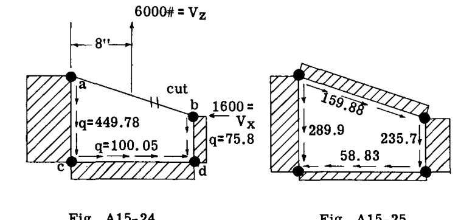

図 A15-24, 図 A15-25

この $q$ の値を図 A15.24 のものに加えることにより、図 A15.25 における最終的な抵抗せん断流パターンが得られる。

#### 解法 2. 主軸法

せん断流系は、もちろん、断面特性と外せん断荷重を梁断面の主軸に参照することによって見出すことができる。せん断流の式は（第 A14 章の式 15 を参照）、

$$q_y = -\frac{V_{zp}}{I_{xp}} \sum z_{pA} - \frac{V_{xp}}{I_{zp}} \sum x_{pA} \quad \text{--- (5)}$$

(下付き文字 p は主軸を表す。)

主軸に関する断面特性は、A13 ページの A13.5 節において同じ梁断面について計算された。値は以下の通りである:-

$$I_{xp} = 75.38 \text{, } I_{zp} = 159.34$$

A13.5 ページからも引用された図 A15.26 は、主軸の位置と、4つのフランジ部材から主軸への距離を示している。

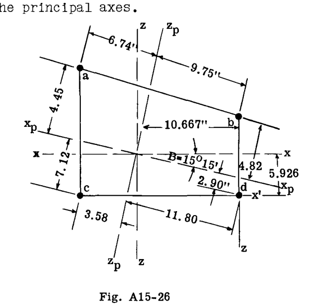

図 A15-26

式 (5) への代入を行う前に、与えられたせん断荷重 $V_z = 6000$ および $V_x = -1600$ を主軸に垂直な方向に分解しなければならない。

$$V_{zp} = 6000 \cos 15^{\circ} 15' - 1600 \sin 15^{\circ} 15' = 5367.9 \text{ lb.}$$

$$V_{xp} = -6000 \sin 15^{\circ} 15' - 1600 \cos 15^{\circ} 15' = -3121.8 \text{ lb.}$$

したがって、

$$\frac{V_{zp}}{I_{xp}} = 71.21 \quad \text{and} \quad \frac{V_{xp}}{I_{zp}} = -19.59$$

式 (5) に代入すると、

$$q_y = -71.21 \sum z_{pA} + 19.59 \sum x_{pA} \quad \text{--- (6)}$$

上部パネル ab において $q_y = 0$ と仮定する。

$$q_{ac} = -71.21 \times 4.45 \times 1 + 19.59 \times (-6.74) \times 1 = -448.92$$

$$q_{cd} = -448.92 - 71.21 (-7.12) .8 + 19.59 (-3.58) .8 = -99.41$$

$$q_{db} = -99.41 - 71.21 (-2.90) .4 + 19.59 \times 11.80 \times .4 = 75.65 \text{ lb/in.}$$

$$q_{ba} = 75.65 - 71.21 (4.82) .5 + 19.59 \times 9.75 \times .5 = 0 \text{ (check)}$$

これらのせん断流は、図 A15.24 に記録されている解法 No.1 で得られたものと実質的に同一である。不一致は計算尺の精度によるものである。

$$\Sigma M_b = 6000 \times 8 - 1600 \times 8 - 448.92 \times 12 \times 16 = -50993 \text{ in. lb.}$$

平衡のために、セルのまわりに 50993 in. lb. を生じさせるために一定のせん断流 $q$ を加えなければならない。この釣り合いせん断流は、

$$q = \frac{M}{2A} = \frac{50993}{2 \times 160} = 159.35 \text{ lb/in.}$$

であり、これは解法 No.1 と同じである。

### 例題 2

図 A15.27 は、複数のフランジ部材を持つ典型的な単一セル翼梁を示している。この梁断面における外せん断荷重は、図のように配置された $V_z = 1000$ および $V_x = 400$ である。内部抵抗せん断流パターンが計算される。

この梁断面は、断面特性の計算が行われた第 A3 章の例題 5 で使用されたものと同一である。

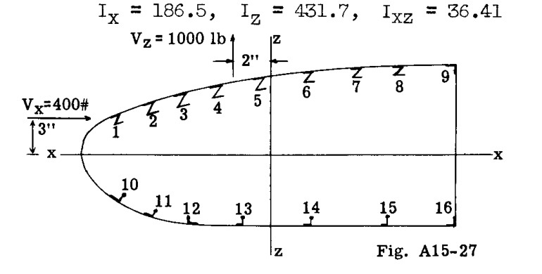

図 A15-27

結果は以下の通りであった:

$$I_x = 186.5 \text{, } I_z = 431.7 \text{, } I_{xz} = 36.41$$

$$V_z = 1000 \text{ lb, } V_x = 400 \text{ lb}$$

#### 解法

解法の K 法が使用される。

$$k_1 = \frac{I_{xz}}{I_x I_z - I_{xz}^2} = \frac{36.41}{186.5 \times 431.7 - 36.41^2} = \frac{36.41}{79185} = .0004598$$

$$k_2 = \frac{I_z}{I_x I_z - I_{xz}^2} = \frac{431.7}{79185} = .005452$$

$$k_3 = \frac{I_x}{I_x I_z - I_{xz}^2} = \frac{186.5}{79185} = .002355$$

$$q_y = (k_3 V_x - k_1 V_z) \sum x A - (k_2 V_z - k_1 V_x) \sum z A$$

上記の式に代入すると、

$$q_y = -(.002355 \times 400 - .0004598 \times 1000) \sum x A - (.005452 \times 1000 - .0004598 \times 400) \sum z A$$

$$q_y = -0.4822 \sum x A - 5.268 \sum z A \quad \text{--- (7)}$$

セル壁上の任意の点におけるせん断流の値は未知であるため、フランジ部材 1 と 10 の間でセル壁が切断されていると仮定し、それによってシートパネル (1-10) 上の $q$ をゼロにする。その後、式 (7) を使用して、パネルのまわりを時計回りに進む際のせん断流を計算する。表 A15.1 の 1 から 10 列目は、式 (7) を解く際に行われた計算を示している。9、10、11列目において、せん断流 $q_y$ の向きをどのように決定するかについては、第 A14 章の A14.6 節を復習されたい。

11列目のせん断流値は、もし与えられた外荷重がこのせん断流力系の図心を通るように配置されていた場合の結果となる。そうではないため、梁断面上の点 (0) である断面の図心まわりの不釣り合いモーメントについて解く。隣接する任意の2つのフランジ部材間のシートパネル上のせん断流力のモーメントは、モーメント中心 (0) と特定のシートパネルの端部から線を引くことによって形成される、囲まれた面積の2倍に $q$ を掛けたものに等しい。図 A15.28 は、この説明を示している。表の 12列目の値 m は、これらの様々な三角形の面積の2倍をリストしている。

点 (0) まわりの、外力と内力のすべてのモーメントをとる。

$$\Sigma M_O = 1000 \times 2 + 400 \times 3 + 17123 = 20323 \text{ in.lb.}$$

(17123 は13列目の合計に等しい)

したがって、平衡のためには、 $-20323$ の負のモーメントが必要である。このモーメントは、セルのまわりに一定の負のせん断流を加えることによって提供され、その大きさは以下に等しい。

$$q = -\frac{M}{2A} = -\frac{20323}{2 \times 493} = -20.6 \text{ lb./in.}$$

( $493$ = セルの面積)

この一定のせん断流を 11列目に加えることにより、14列目に最終的なせん断流が得られる。図 A15.29 は、真のせん断流パターンを示している。

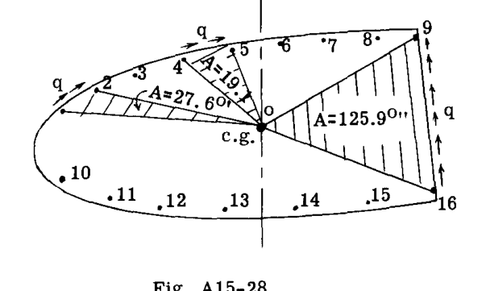

図 A15-28

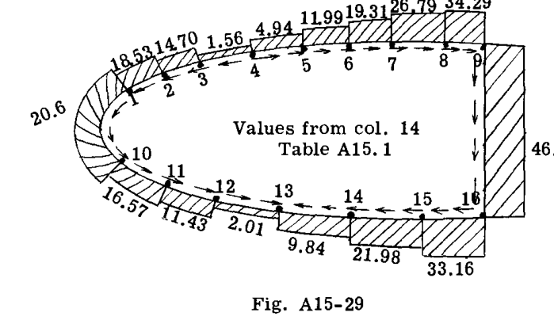

図 A15-29

| 1 | 2 | 3 | 4 | 5 | 6 | 7 | 8 | 9 | 10 | 11 | 12 | 13 | 14 |
| --- | --- | --- | --- | --- | --- | --- | --- | --- | --- | --- | --- | --- | --- |
| Member | Area $A$ | Arm $Z$ | $ZA$ | Arm $X$ | $XA$ | $\Sigma ZA$ | $\Sigma XA$ | $q_y = -0.4822 (\Sigma XA)$ | $q_y = -5.268 (\Sigma ZA)$ | $q_{xz} = (col 9 + col 10)$ | $m$ sq. in. | $q_{xzm}$ | Final $q = q_{xz} - 20.6$ |
| 1 | 0.14 | 4.396 | 0.615 | -17.41 | -2.437 | 0 | 0 | 0 | 0 | 0 | 0 | 0 | -20.6 |
| 2 | 0.14 | 6.446 | 0.902 | -13.54 | -1.896 | 0.615 | -2.437 | 1.175 | -3.240 | 2.065 | 55.2 | 114 | -18.53 |
| 3 | 0.38 | 7.396 | 2.810 | -9.11 | -3.462 | 1.517 | -4.333 | 2.089 | -7.991 | 5.902 | 44.2 | 261 | -14.70 |
| 4 | 0.17 | 7.766 | 1.320 | -5.44 | -0.925 | 4.327 | -7.795 | 3.758 | -22.794 | 19.036 | 32.0 | 609 | -1.56 |
| 5 | 0.17 | 7.946 | 1.351 | -0.86 | -0.146 | 5.647 | -8.720 | 4.205 | -29.748 | 25.543 | 38.2 | 976 | 4.94 |
| 6 | 0.17 | 7.896 | 1.342 | 3.14 | 0.534 | 6.988 | -8.866 | 4.275 | -36.865 | 32.590 | 33.0 | 1075 | 11.99 |
| 7 | 0.17 | 7.696 | 1.308 | 7.14 | 1.214 | 8.340 | -8.332 | 4.017 | -43.935 | 39.908 | 33.2 | 1325 | 19.31 |
| 8 | 0.17 | 7.296 | 1.240 | 11.74 | 1.996 | 9.648 | -7.118 | 3.432 | -50.825 | 47.393 | 40.2 | 1905 | 26.79 |
| 9 | 0.29 | 6.896 | 2.000 | 15.39 | 4.463 | 10.888 | -5.722 | 2.470 | -57.358 | 54.888 | 32.6 | 1789 | 34.29 |
| 16 | 0.35 | -8.411 | -2.964 | 15.39 | 5.386 | 12.888 | -0.659 | 0.318 | -67.894 | 67.576 | 251.8 | 1702 | 46.98 |
| 15 | 0.31 | -8.224 | -2.587 | 9.64 | 2.988 | 9.924 | 4.727 | -2.279 | -52.280 | 54.559 | 46 | 2509 | 33.16 |
| 14 | 0.31 | -7.734 | -2.395 | 3.32 | 1.629 | 7.327 | 7.715 | -3.720 | -38.862 | 42.582 | 48.2 | 2052 | 21.98 |
| 13 | 0.31 | -7.004 | -2.111 | -2.96 | -0.917 | 4.982 | 8.744 | -4.216 | -26.245 | 30.444 | 46.4 | 1413 | 9.84 |
| 12 | 0.28 | -5.554 | -1.554 | -9.11 | -2.551 | 2.813 | 7.827 | -3.774 | -14.819 | 18.59 | 47.6 | 885 | -2.01 |
| 11 | 0.17 | -4.504 | -0.766 | -13.54 | -2.302 | 1.259 | 5.276 | -2.544 | -6.632 | 9.176 | 36.6 | 336 | -11.43 |
| 10 | 0.17 | -2.904 | -0.493 | -17.51 | -2.976 | 0.493 | 2.974 | -1.434 | -2.597 | 4.031 | 42.6 | 172 | -16.57 |
| 1 |  |  |  |  |  | 0 | 0 |  |  | 0 |  | 0 | -20.6 |
|  |  |  |  |  |  |  |  |  |  |  |  | $\Sigma 17123$ |  |

## A15.9 2セル - 複数フランジ梁。1軸対称。

図 A15.30 は、10のフランジストリンガーを持つ 2セルの片持ち梁を示している。断面は一定である。示すように作用する 1000 lb. の荷重に抵抗する際の内部せん断流を決定することが求められている。簡単にするために、上部および下部のシートカバーと 3つの垂直ウェブは、曲げ曲げ荷重を受けるのに無効であるとみなされる。梁断面は X 軸に関して対称であるため、梁は与えられた外荷重に抵抗して、ねじれを伴わずにこの軸まわりに曲がる。X 軸に関する断面の慣性モーメントは 250 $\text{in.}^4$ である。

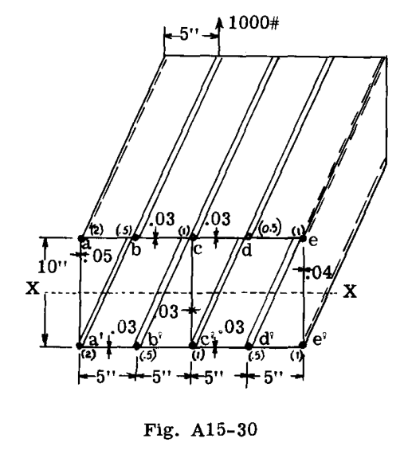

図 A15-30